# Differential Binding Site Results for GSE95632

### Boxplots for top 20 differentially binding sites

Binding sites were ranked by pvalue. Counts have been normalized by sequencing depth. Apply log2-transformed values from plotting.

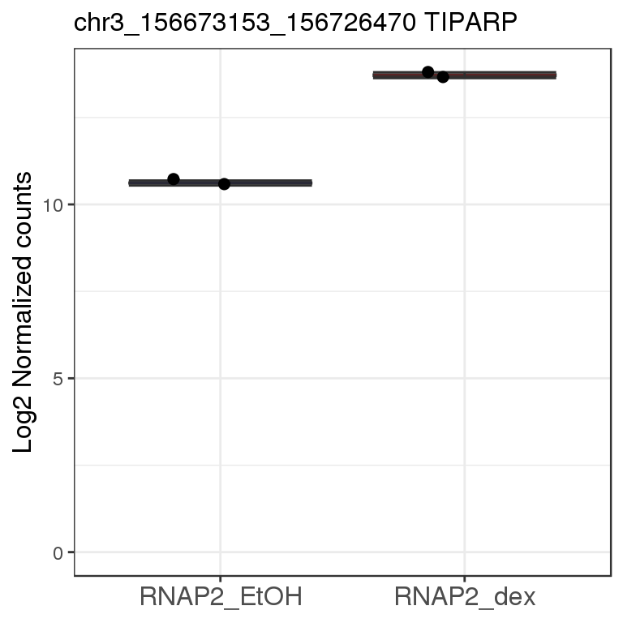

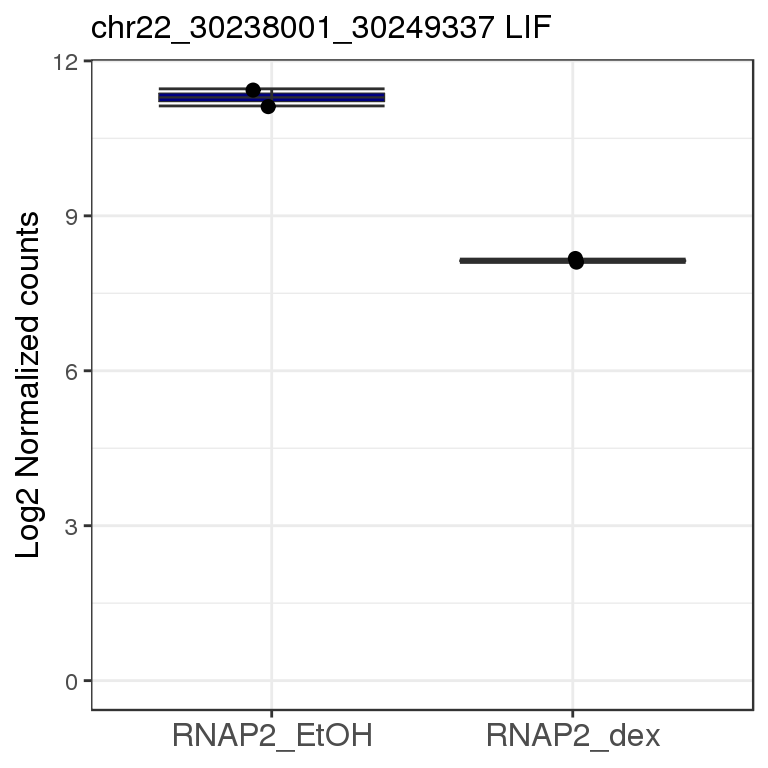

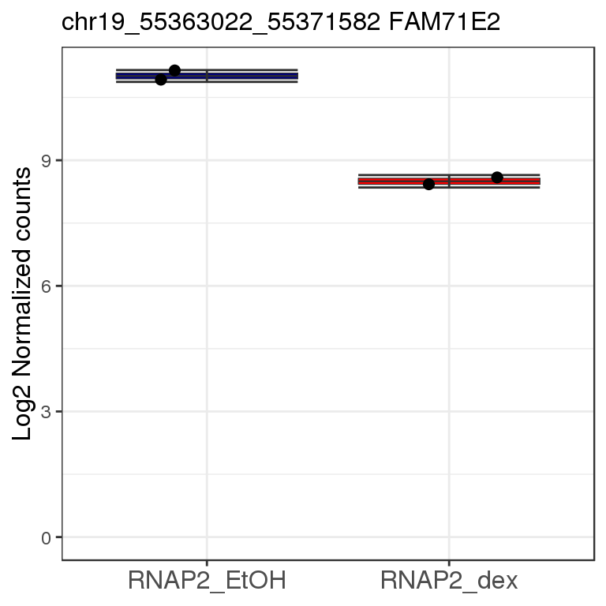

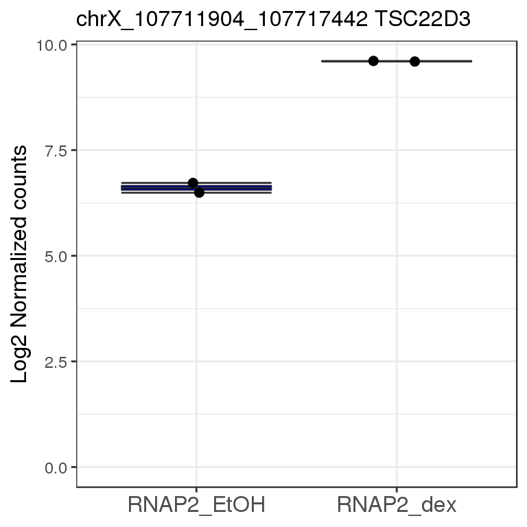

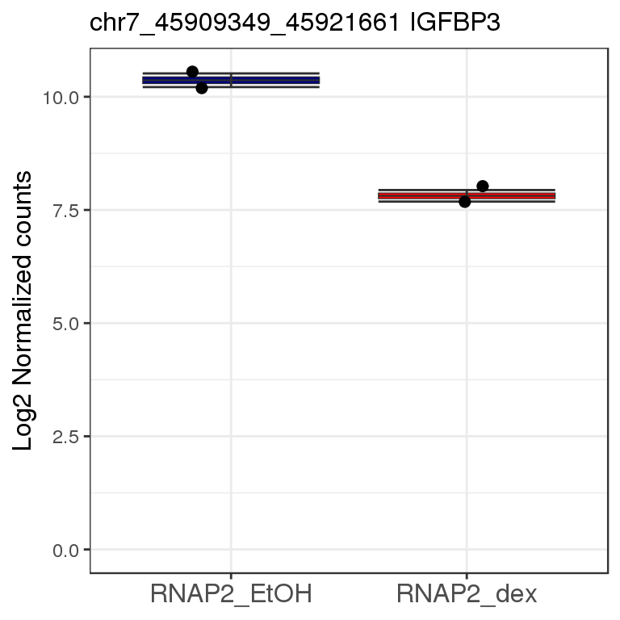

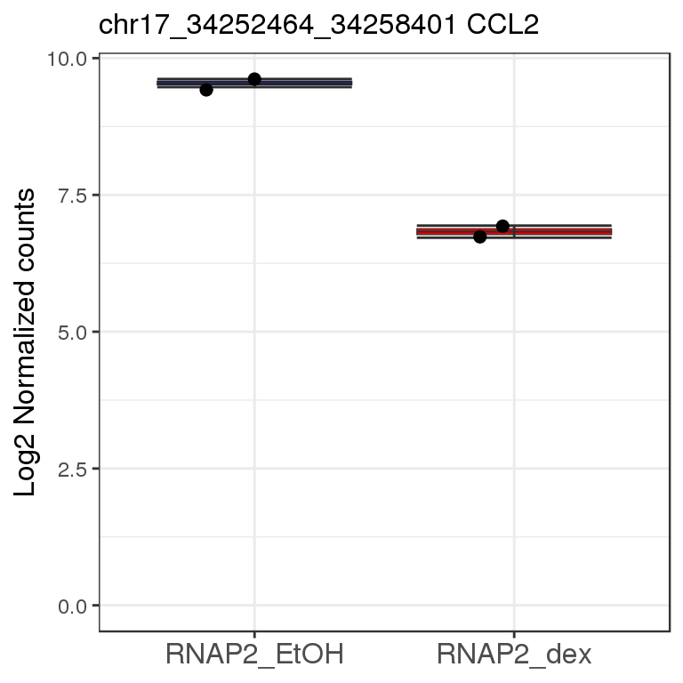

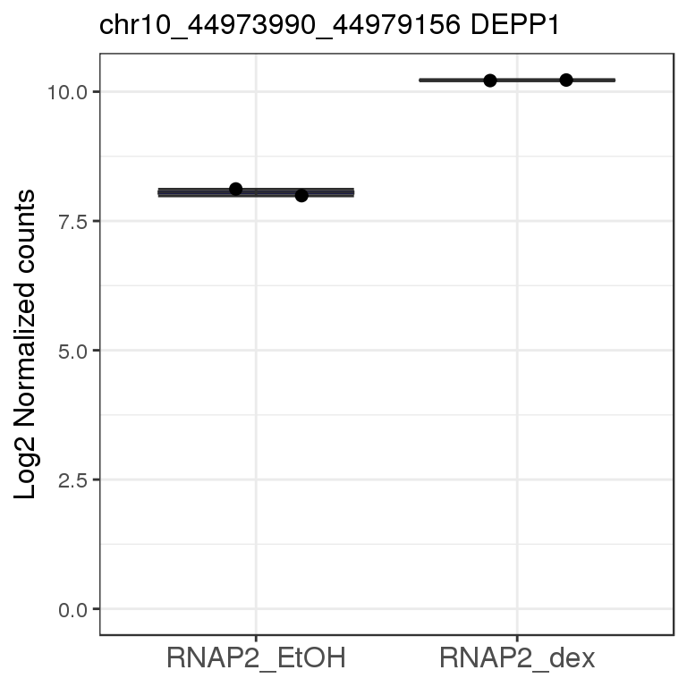

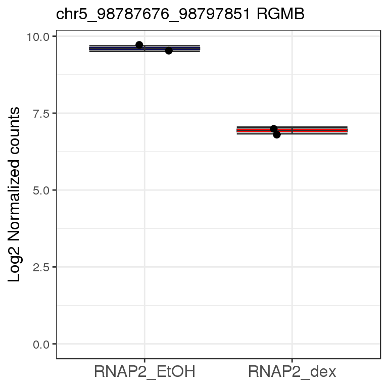

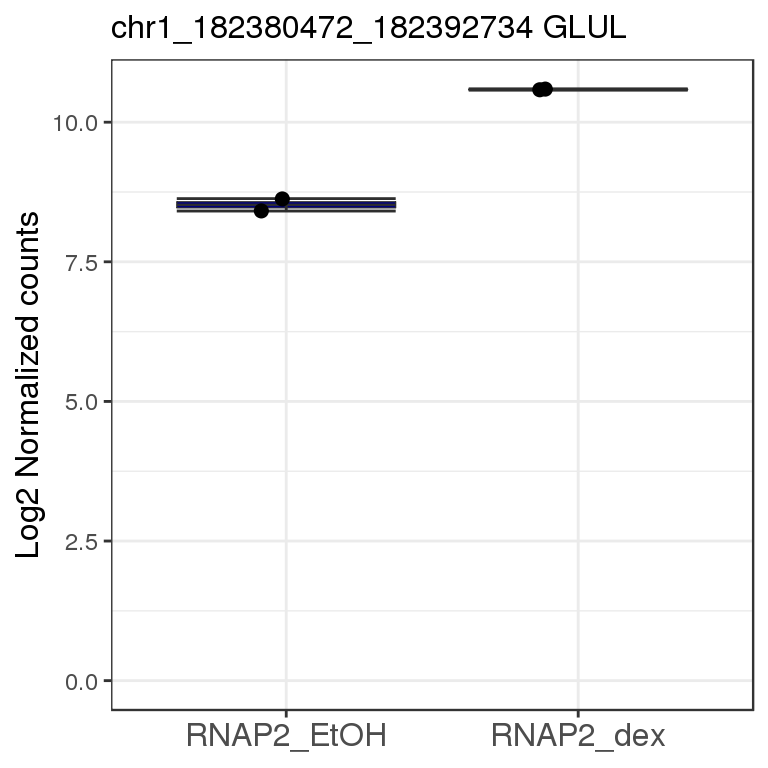

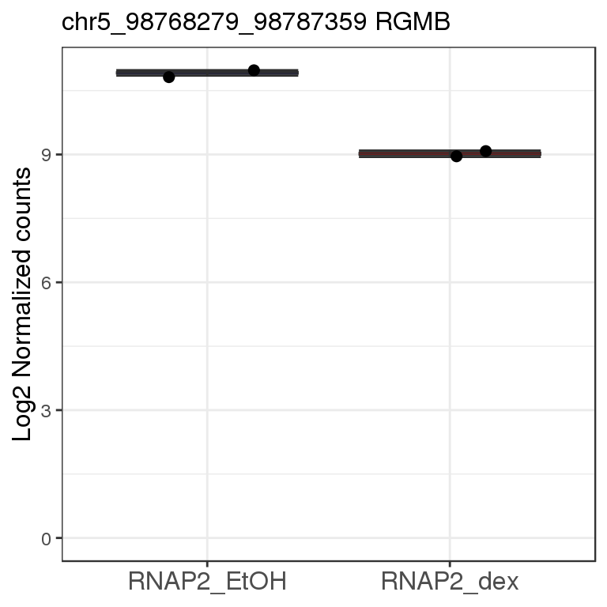

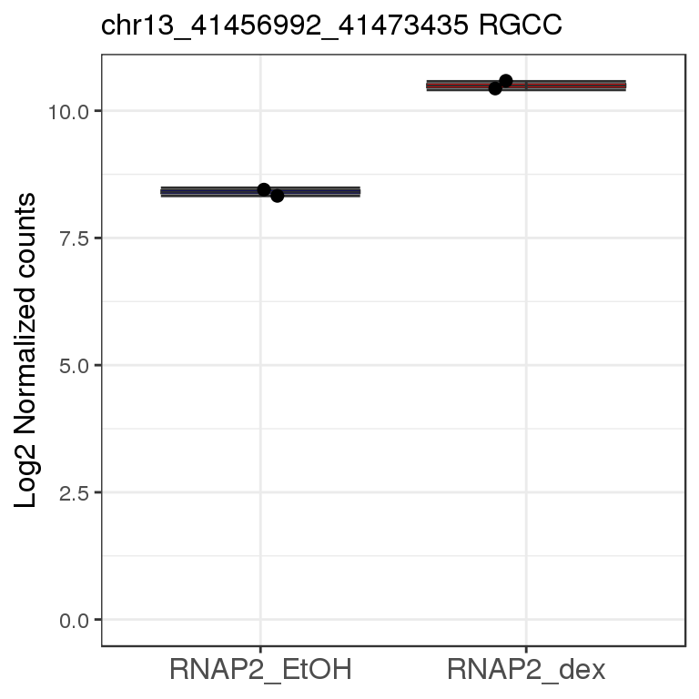

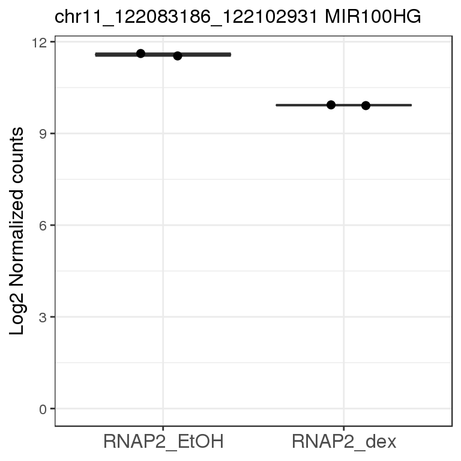

[8 more figures not shown]

### Profile of significant peaks binding to TSS regions

Heatmap of ChIP binding to TSS regions (left).

Average Profile of ChIP peaks binding to TSS region (right).

[output not shown]

[output not shown]

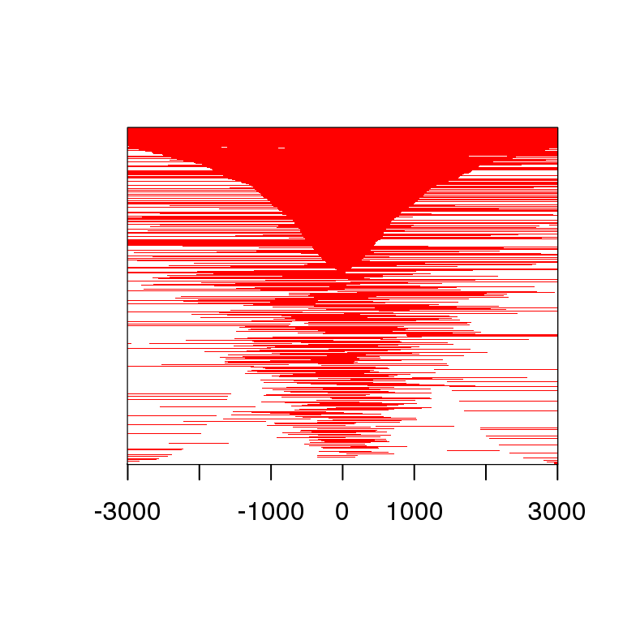

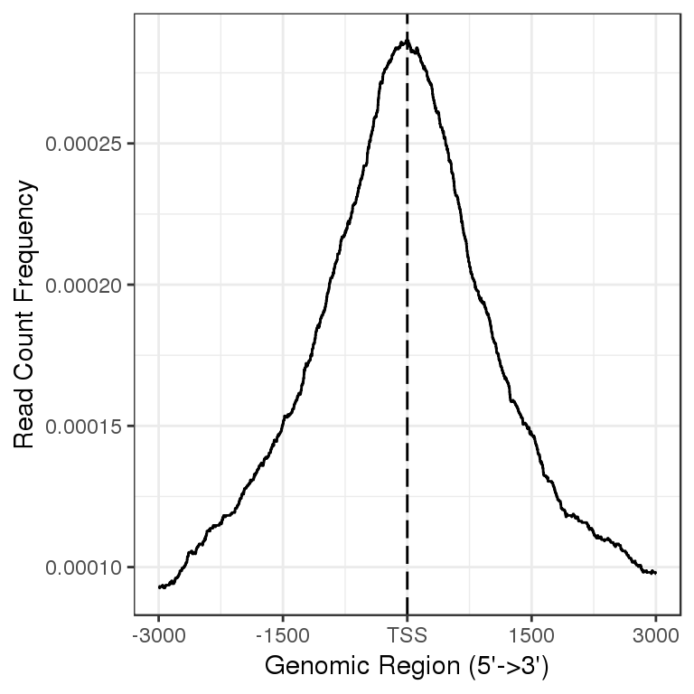

### Distribution of significant peaks’ genomic annotation

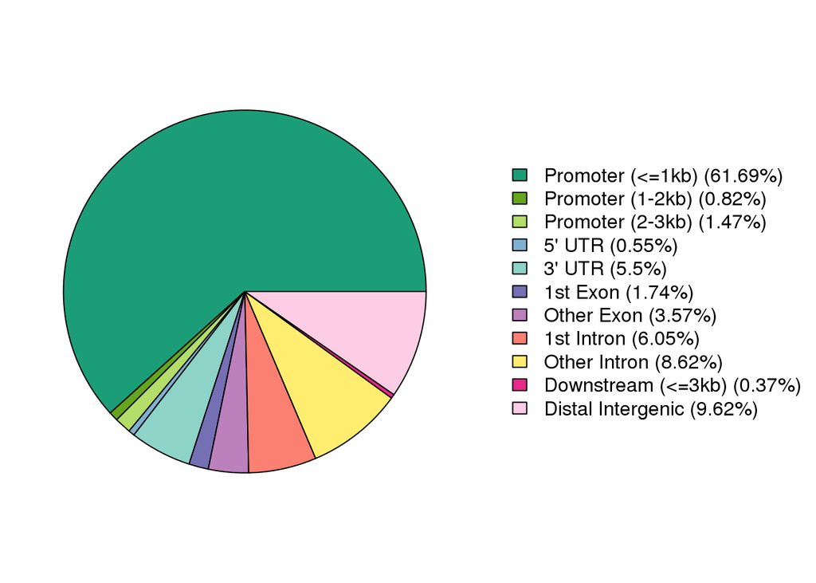

### Distribution of TF-binding loci relative to TSS

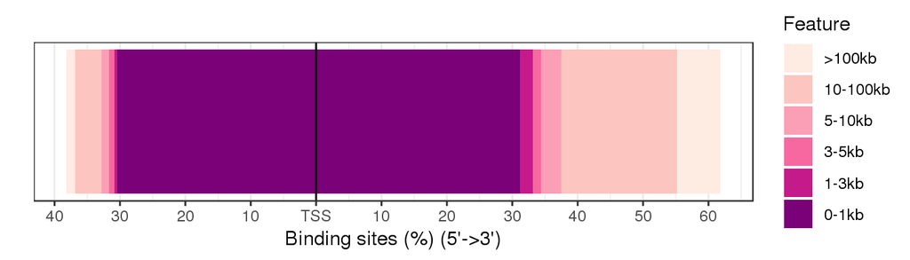

**R version 3.4.3 (2017-11-30)**

**Platform:** x86_64-redhat-linux-gnu (64-bit)

**locale:** *LC_CTYPE=en_US.UTF-8*, *LC_NUMERIC=C*, *LC_TIME=en_US.UTF-8*, *LC_COLLATE=en_US.UTF-8*, *LC_MONETARY=en_US.UTF-8*, *LC_MESSAGES=en_US.UTF-8*, *LC_PAPER=en_US.UTF-8*, *LC_NAME=C*, *LC_ADDRESS=C*, *LC_TELEPHONE=C*, *LC_MEASUREMENT=en_US.UTF-8* and *LC_IDENTIFICATION=C*

**attached base packages:** *parallel*, *stats4*, *stats*, *graphics*, *grDevices*, *utils*, *datasets*, *methods* and *base*

**other attached packages:** *bindrcpp(v.0.2.2)*, *pander(v.0.6.1)*, *viridis(v.0.5.0)*, *viridisLite(v.0.3.0)*, *RColorBrewer(v.1.1-2)*, *gplots(v.3.0.1)*, *ggplot2(v.3.0.0)*, *devtools(v.1.13.5)*, *DT(v.0.4)*, *tidyr(v.0.8.1)*, *ChIPseeker(v.1.14.2)*, *DiffBind(v.2.6.6)*, *SummarizedExperiment(v.1.8.1)*, *DelayedArray(v.0.4.1)*, *matrixStats(v.0.54.0)*, *TxDb.Hsapiens.UCSC.hg38.knownGene(v.3.4.0)*, *GenomicFeatures(v.1.30.3)*, *GenomicRanges(v.1.30.3)*, *GenomeInfoDb(v.1.14.0)*, *org.Hs.eg.db(v.3.5.0)*, *AnnotationDbi(v.1.40.0)*, *IRanges(v.2.12.0)*, *S4Vectors(v.0.16.0)*, *Biobase(v.2.38.0)*, *BiocGenerics(v.0.24.0)* and *rmarkdown(v.1.9)*

**loaded via a namespace (and not attached):** *backports(v.1.1.2)*, *GOstats(v.2.44.0)*, *Hmisc(v.4.1-1)*, *fastmatch(v.1.1-0)*, *plyr(v.1.8.4)*, *igraph(v.1.2.2)*, *lazyeval(v.0.2.1)*, *GSEABase(v.1.40.1)*, *splines(v.3.4.3)*, *BatchJobs(v.1.7)*, *BiocParallel(v.1.12.0)*, *crosstalk(v.1.0.0)*, *gridBase(v.0.4-7)*, *amap(v.0.8-16)*, *digest(v.0.6.16)*, *htmltools(v.0.3.6)*, *GOSemSim(v.2.4.1)*, *GO.db(v.3.5.0)*, *gdata(v.2.18.0)*, *magrittr(v.1.5)*, *checkmate(v.1.8.5)*, *memoise(v.1.1.0)*, *BBmisc(v.1.11)*, *cluster(v.2.0.6)*, *limma(v.3.34.9)*, *Biostrings(v.2.46.0)*, *annotate(v.1.56.2)*, *systemPipeR(v.1.12.0)*, *prettyunits(v.1.0.2)*, *colorspace(v.1.3-2)*, *blob(v.1.1.1)*, *ggrepel(v.0.7.0)*, *dplyr(v.0.7.6)*, *RCurl(v.1.95-4.10)*, *jsonlite(v.1.5)*, *TxDb.Hsapiens.UCSC.hg19.knownGene(v.3.2.2)*, *graph(v.1.56.0)*, *genefilter(v.1.60.0)*, *bindr(v.0.1.1)*, *brew(v.1.0-6)*, *survival(v.2.41-3)*, *sendmailR(v.1.2-1)*, *glue(v.1.3.0)*, *gtable(v.0.2.0)*, *zlibbioc(v.1.24.0)*, *XVector(v.0.18.0)*, *UpSetR(v.1.3.3)*, *Rgraphviz(v.2.22.0)*, *scales(v.1.0.0)*, *DOSE(v.3.4.0)*, *pheatmap(v.1.0.10)*, *DBI(v.0.8)*, *edgeR(v.3.20.9)*, *Rcpp(v.0.12.18)*, *plotrix(v.3.7-3)*, *htmlTable(v.1.11.2)*, *xtable(v.1.8-2)*, *progress(v.1.1.2)*, *foreign(v.0.8-69)*, *bit(v.1.1-12)*, *Formula(v.1.2-2)*, *AnnotationForge(v.1.20.0)*, *htmlwidgets(v.1.2)*, *httr(v.1.3.1)*, *fgsea(v.1.4.1)*, *acepack(v.1.4.1)*, *pkgconfig(v.2.0.2)*, *XML(v.3.98-1.10)*, *nnet(v.7.3-12)*, *locfit(v.1.5-9.1)*, *labeling(v.0.3)*, *tidyselect(v.0.2.4)*, *rlang(v.0.2.2)*, *reshape2(v.1.4.3)*, *later(v.0.7.3)*, *munsell(v.0.5.0)*, *tools(v.3.4.3)*, *RSQLite(v.2.0)*, *evaluate(v.0.10.1)*, *stringr(v.1.3.0)*, *yaml(v.2.1.18)*, *knitr(v.1.20)*, *bit64(v.0.9-7)*, *caTools(v.1.17.1)*, *purrr(v.0.2.5)*, *RBGL(v.1.54.0)*, *mime(v.0.5)*, *DO.db(v.2.9)*, *biomaRt(v.2.34.2)*, *rstudioapi(v.0.7)*, *compiler(v.3.4.3)*, *geneplotter(v.1.56.0)*, *tibble(v.1.4.2)*, *stringi(v.1.2.3)*, *lattice(v.0.20-35)*, *Matrix(v.1.2-12)*, *pillar(v.1.2.1)*, *data.table(v.1.11.4)*, *bitops(v.1.0-6)*, *httpuv(v.1.4.3)*, *rtracklayer(v.1.38.3)*, *qvalue(v.2.10.0)*, *R6(v.2.2.2)*, *latticeExtra(v.0.6-28)*, *hwriter(v.1.3.2)*, *RMySQL(v.0.10.15)*, *promises(v.1.0.1)*, *ShortRead(v.1.36.1)*, *KernSmooth(v.2.23-15)*, *gridExtra(v.2.3)*, *boot(v.1.3-20)*, *gtools(v.3.5.0)*, *assertthat(v.0.2.0)*, *DESeq2(v.1.18.1)*, *Category(v.2.44.0)*, *rprojroot(v.1.3-2)*, *rjson(v.0.2.20)*, *withr(v.2.1.2)*, *GenomicAlignments(v.1.14.2)*, *Rsamtools(v.1.30.0)*, *GenomeInfoDbData(v.1.0.0)*, *rpart(v.4.1-11)*, *grid(v.3.4.3)*, *rvcheck(v.0.1.0)*, *shiny(v.1.1.0)* and *base64enc(v.0.1-3)*